# An Analysis of the Effect of Gender, Criminal History, and Education on Income using the National Longitudinal Survey of Youth, 1997 (NLSY97)

Another effect of adding an interaction variable between sex and race is that being divorced which was on the edge of statistical significance in the original model, with a p-value of 0.0537522, would now be considered statistically significant with a p-value of 0.038099 when our `sex * race` interaction interaction variable is added. This makes sense as it follows the general trend showing how a few incomes at the top levels were skewing the results across multiple other variables when they were supressed by a topcoded value.

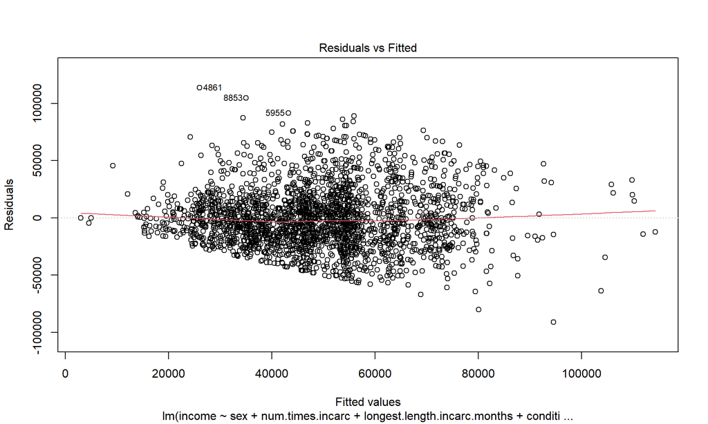

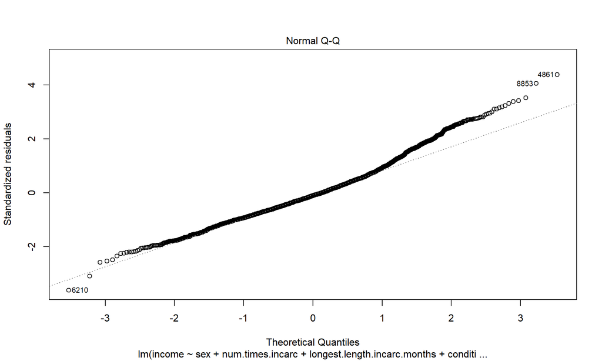

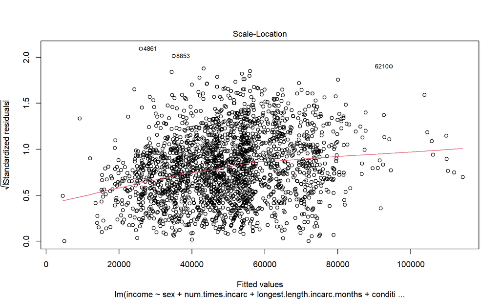

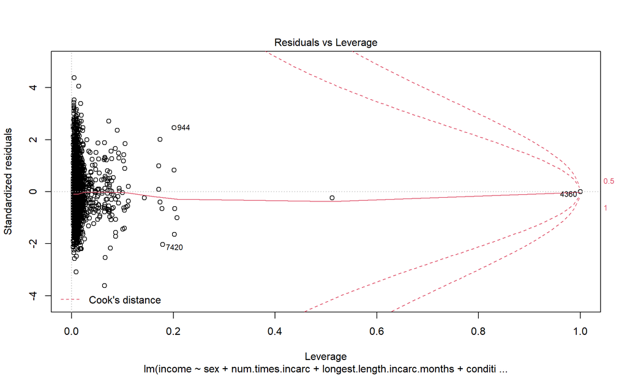

**Residual vs Fitted Plot**

The residual vs. fitted plot continue to show that, for the lower fitted values, there is clustering around 0 and as the fitted values increase, deviation away from a residual of 0 increases, suggesting that this model is still overestimating income in lower income brackets, very slightly underestimating income in the middle brackets, and overestimating income in higher income brackets. The deviation in the upper tail is mostly similar to Model #2 but corrects slightly for the overestimation of income in the higher brackets.

**Normal QQ Plot**

The normal QQ plot shows a very similar trend to the residual vs. fitted plot in the Model #2 as we might expect from looking at the residual vs. fitted and while there are still large deviations in the upper tail, this model corrects very slightly for incomes in higher brackets.

**Scale-Location Plot**

As the fitted values increase, the variance still increases steadily, holding nearly identically with Model #2 but with some slight variation at the very top and bottom of the range.

**Outliers & The Residuals vs Leverage Plot**

The residuals vs leverage plot shows that the outliers in Model #2 remain present and adds some additional outliers as your income rises.

**Conclusions from the Plot**

Adding the sex*race interaction term appears to change very little that removing top coding from income didn’t already change, while it addresses some minor issues with the model it appears to also introduce new outliers making it appear potentially redundant.

**How does adding the sex/race interaction variable change predictions for the Income Gender Gap by Race?**

Now that we’ve reviewed the analysis of the gender income gap we wanted to see exactly how large this gender based income gap was between different racial groups in the main effects model versus our model adding a sex*race interaction term.

| race | income.gap |
| --- | --- |
| Non-Black/ Non-Hispanic | 13177 |
| Black | 5356 |
| Hispanic | 13563 |
| Mixed Race (Non Hispanic) | 14836 |

It appears the the main effects model is effective in showing general trends but misses the mark when predicting values for the size of the income gap by sex. At 10,309 , the income gap between Black men and women is nearly double what is predicted by the main effects model. However, we see that the similarity in income gap between Hispanic men and women and Non-Black/Non-Hispanic men and women is pretty accurate but it does underestimate the size of that gap by about 4,000 dollars.

The main effects model is most inaccurate when considering Mixed Race, Non-Hispanic respondents. It predicts a 14,836 dollar gap which is far off the 5,275 dollar gap shown by the model. We suspect this is due to the small sample size present of Mixed Race, Non-Hispanic respondents as compared to other groups.

**Testing the Significance of Adding an Interaction Variable on the Sex * Race Term**

In order to determine how we should proceed with the insights gleaned from adding a `sex * race`interaction variable we tested the statistical significance of our findings with an ANOVA test.

```
## Analysis of Variance Table
##
## Model 1: income ~ sex + num.times.incarc + longest.length.incarc.months +
##     condition.limiting.work + citizenship + urban.status.age.12 +
##     residential.dad.highest.grade.completed + residential.mom.highest.grade.completed +
##     race + num.children.under.6 + highest.degree.earned + marital.status +
##     age.in.2017
## Model 2: income ~ sex + num.times.incarc + longest.length.incarc.months +
##     condition.limiting.work + citizenship + urban.status.age.12 +
##     residential.dad.highest.grade.completed + residential.mom.highest.grade.completed +
##     race + num.children.under.6 + highest.degree.earned + marital.status +
##     age.in.2017 + sex:race
##   Res.Df           RSS Df  Sum of Sq      F  Pr(>F)
## 1   2346 1595000619595
## 2   2343 1590698444288  3 4302175307 2.1123 0.09663 .
## ---
## Signif. codes:  0 '***' 0.001 '**' 0.01 '*' 0.05 '.' 0.1 ' ' 1
```

Reviewing our results, we see that while the p-value of 0.096629 meets what we wouldlook for when assessing for 90% confidence of statistical significance, it falls short of the threshold required to reject the null hypothesis. Therefore we fail to reject the null hypothesis that the income gap is the same across all racial categories at a significance level of 0.05.

#### Model 6: Distilling the Impact of Marital Status by Sex on Income

**Is the Effect of Marital Status Statistically Significant?:**

In Model #1 and Model #2 we see that being married has a statistically significant effect on your income. Notably though, in Model 1 being divorced does not have a significant effect and divorce falls just slightly out of the range of having a statistically significant effect in Model #2. In Model #3 divorce also becomes statistically significant. To see if marital status is a statistically significant variable in our model we ran an ANOVA test.

```
## Analysis of Variance Table
##
## Model 1: income ~ sex + num.times.incarc + longest.length.incarc.months +
##     condition.limiting.work + citizenship + urban.status.age.12 +
##     residential.dad.highest.grade.completed + residential.mom.highest.grade.completed +
##     race + num.children.under.6 + highest.degree.earned + age.in.2017
## Model 2: income ~ sex + num.times.incarc + longest.length.incarc.months +
##     condition.limiting.work + citizenship + urban.status.age.12 +
##     residential.dad.highest.grade.completed + residential.mom.highest.grade.completed +
##     race + num.children.under.6 + highest.degree.earned + marital.status +
##     age.in.2017
##   Res.Df           RSS Df   Sum of Sq      F       Pr(>F)
## 1   2351 1621581006295
## 2   2346 1595000619595  5 26580386700 7.8191 0.0000002608 ***
## ---
## Signif. codes:  0 '***' 0.001 '**' 0.01 '*' 0.05 '.' 0.1 ' ' 1
```

When we run the ANOVA test we see the p-value of 0.0000003 is sufficiently small for us to say that marital status is a statistically significant predictor of income, and is influencing our model.

**Adding an interaction term between sex and marital status**

Our tabular and graphical summaries above illustrated clearly that marital status is not uniform between men and women, with more women being married and divorced. The ANOVA test above additionally tells us that marital status has a statistically significant effect on income. With these facts in mind, we created an interaction variable for `sex * marital.status` to see how marital status interacts with sex to influence our model.

|  | Estimate | Std. Error | t value | Pr(>\|t\|) |
| --- | --- | --- | --- | --- |
| (Intercept) | -4288 | 13663 | -0.31 | 0.7536 |
| sexMale | 7580 | 1884 | 4.02 | 0.0001 |
| num.times.incarc | -2568 | 1327 | -1.94 | 0.0530 |
| longest.length.incarc.months | -117 | 92 | -1.28 | 0.2002 |
| condition.limiting.workYes | -8927 | 2528 | -3.53 | 0.0004 |
| condition.limiting.workValid Skip | -30238 | 25942 | -1.17 | 0.2439 |
| condition.limiting.workDon’t Know | -39026 | 25989 | -1.50 | 0.1333 |
| condition.limiting.workRefused to Answer | 19920 | 26119 | 0.76 | 0.4457 |
| citizenshipUnknown, not born in the U.S. | 5288 | 3152 | 1.68 | 0.0936 |
| citizenshipUnknown, birthplace unknown | 6019 | 2275 | 2.65 | 0.0082 |
| urban.status.age.12Rural | -2386 | 1269 | -1.88 | 0.0601 |
| urban.status.age.12Unknown | -1231 | 5591 | -0.22 | 0.8257 |
| residential.dad.highest.grade.completed | 92 | 229 | 0.40 | 0.6877 |
| residential.mom.highest.grade.completed | 589 | 247 | 2.39 | 0.0169 |
| raceBlack | -5132 | 1567 | -3.27 | 0.0011 |
| raceHispanic | 242 | 1691 | 0.14 | 0.8863 |
| raceMixed Race (Non Hispanic) | -9914 | 6351 | -1.56 | 0.1186 |
| num.children.under.6 | -1277 | 752 | -1.70 | 0.0894 |
| highest.degree.earnedGED | 5418 | 3462 | 1.57 | 0.1177 |
| highest.degree.earnedHigh School Diploma | 11556 | 2949 | 3.92 | 0.0001 |
| highest.degree.earnedAssociate | 21354 | 3429 | 6.23 | 0.0000 |
| highest.degree.earnedBachelors | 28629 | 3116 | 9.19 | 0.0000 |
| highest.degree.earnedMasters | 35075 | 3602 | 9.74 | 0.0000 |
| highest.degree.earnedPhD | 59911 | 8785 | 6.82 | 0.0000 |
| highest.degree.earnedProfessional Degree (DDS, JD, MD) | 66555 | 7166 | 9.29 | 0.0000 |
| highest.degree.earnedNon-Interview | 14157 | 5634 | 2.51 | 0.0121 |
| highest.degree.earnedInvalid Skip | 23532 | 7307 | 3.22 | 0.0013 |
| marital.statusMarried | 296 | 1773 | 0.17 | 0.8673 |
| marital.statusSeparated | 3119 | 6634 | 0.47 | 0.6383 |
| marital.statusDivorced | -1142 | 2762 | -0.41 | 0.6793 |
| marital.statusWidowed | -10762 | 11714 | -0.92 | 0.3583 |
| marital.statusInvalid Skip | -11996 | 11683 | -1.03 | 0.3046 |
| age.in.2017 | 553 | 386 | 1.44 | 0.1513 |
| sexMale:marital.statusMarried | 13727 | 2354 | 5.83 | 0.0000 |
| sexMale:marital.statusSeparated | -3736 | 9123 | -0.41 | 0.6822 |
| sexMale:marital.statusDivorced | 9161 | 3990 | 2.30 | 0.0218 |
| sexMale:marital.statusWidowed | 64308 | 28500 | 2.26 | 0.0241 |
| sexMale:marital.statusInvalid Skip | 23355 | 14314 | 1.63 | 0.1029 |

**How Large is the Income Gap Between Marital Statuses?**

From the summary we see a number of very interesting results.

This positive correlation with income is also true for married women who on average make 1,438 dollars more than their counterparts who are divorced.

However being separated has far more positive correlation with income for women than men, with separated women making on average 2,823 dollars more than married women.

**How Large is the Income Gender Gap between Different Marital Statuses?**

It is important to note that the sample size for women and men who were widowed is very small. In fact, only 4 men and 19 women in the entire dataset have been widowed. These small sample sizes likley explain at least some of the high irregularity of the result regarding widows compared to other marital status groups.

But both outsize the only 3,844 dollar income gap between men and women who are classified as separated. While the income gap persists across all marital statuses, the relative size of that income gap is heavily dependent on the specifics of the marital status.

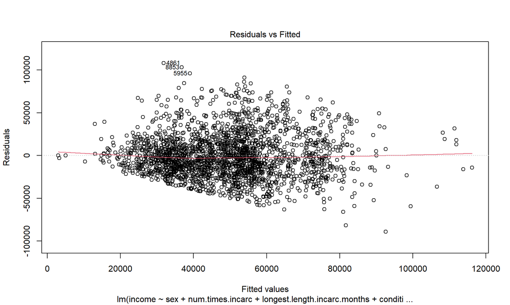

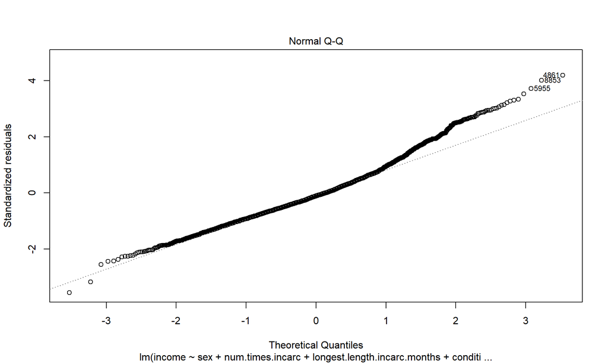

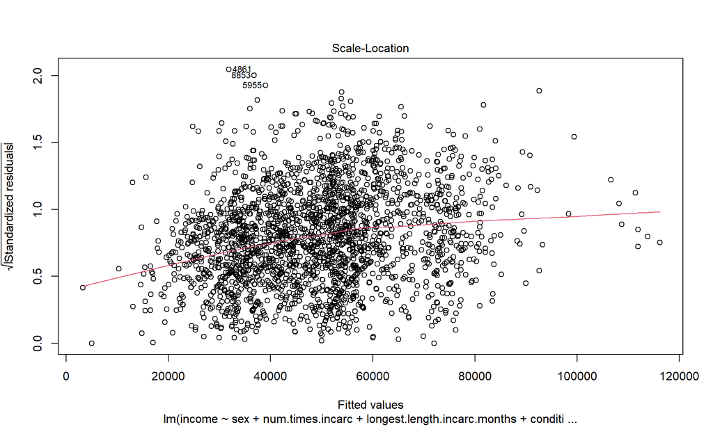

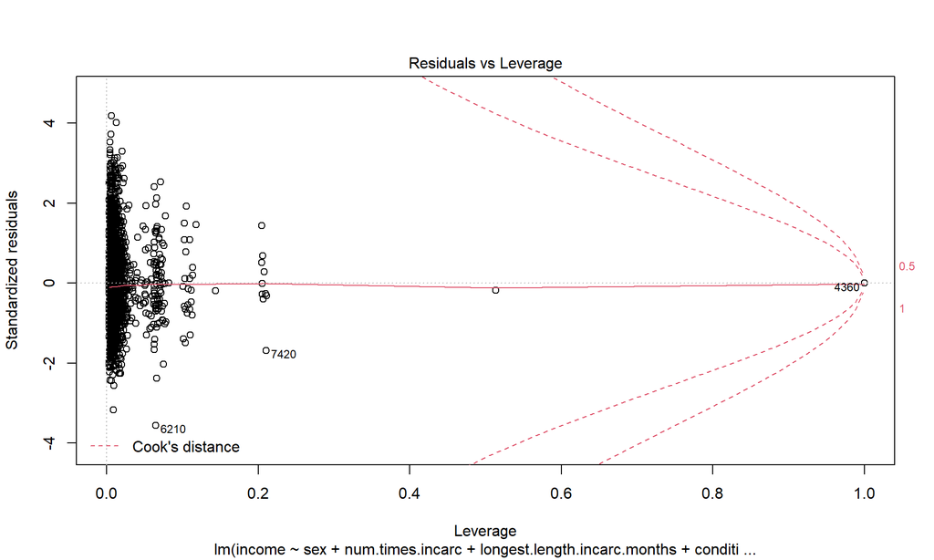

**Residual vs Fitted Plot**

The residual vs. fitted plot continues to show that, for the lower fitted values, there is clustering around 0 and as the fitted values increase, deviation away from a residual of 0 increases, suggesting that this model is still overestimating income in lower income brackets. However, adding the interaction variable between sex and marital status does seem to correct much of the overestimation of income in the higher brackets.

**Normal QQ Plot**

The normal QQ plot shows a mostly similar trend to the residual vs. fitted plot in Models 2 and 3, but as the residual vs. fitted plot alludes to there is measurable correction for incomes in the higher tail of the range, but there is still a trend of significant deviation.

**Scale-Location Plot**

As the fitted values increase, the variance still increases steadily like Model #2 and #3 but the increase is sharper at the bottom of the range and slightly flatter at the top.

**Outliers & The Residuals vs Leverage Plot**

The residuals vs leverage plot show that many of the outliers in Model #2 remain present but it corrects for some of the outliers toward the top of the income range with standardized residuals below 0.

**Conclusions from the Plot**

Adding the `sex*marital` coefficient appears to make small but meaningful changes at the higher end of the income spectrum that removing top coding from income didn’t address. It did not solve some of the issues with the model at the lower end of the range, but the better fit at the top of the range suggest the addition of a `sex*marital` interaction term improves the model in a meaningful way.

**Predicted Income Gender Gap between Different Marital Statuses with and without the Interaction Variable**

| marital.status | income.gap |
| --- | --- |
| Never-marrried | 5804 |
| Married | 17652 |
| Separated | -4974 |
| Divorced | 10690 |
| Widowed | 31667 |
| Non-Interview | NaN |
| Invalid Skip | 12499 |

We see from looking at the predicted income gap from the main effects model that while the trend of the values remains the same, the addition of an interaction variable accounts for more of a significant gap in income between widowed men and women and offers a clearer picture of the income gap between married men and women.

The main effects model does however catch the positive effect that separation has on womens income and the negative effect it has on mens and is one of the lone negative coefficients for men’s income we’ve seen in our analysis.

**Testing the Significance of Adding an Interaction Variable on the Sex * Marital Status Term**

To determine if the effects of the addition of the `sex^marital` coefficient to the model were statistically significant we ran an ANOVA test comparing our two models.

```
## Analysis of Variance Table
##
## Model 1: income ~ sex + num.times.incarc + longest.length.incarc.months +
##     condition.limiting.work + citizenship + urban.status.age.12 +
##     residential.dad.highest.grade.completed + residential.mom.highest.grade.completed +
##     race + num.children.under.6 + highest.degree.earned + marital.status +
##     age.in.2017
## Model 2: income ~ sex + num.times.incarc + longest.length.incarc.months +
##     condition.limiting.work + citizenship + urban.status.age.12 +
##     residential.dad.highest.grade.completed + residential.mom.highest.grade.completed +
##     race + num.children.under.6 + highest.degree.earned + marital.status +
##     age.in.2017 + sex:marital.status
##   Res.Df           RSS Df   Sum of Sq      F       Pr(>F)
## 1   2346 1595000619595
## 2   2341 1567735263642  5 27265355953 8.1427 0.0000001246 ***
## ---
## Signif. codes:  0 '***' 0.001 '**' 0.01 '*' 0.05 '.' 0.1 ' ' 1
```

We see that the p-value of 0.0000001 meets the threshold required to reject the null hypothesis. Therefore we can reject the null hypothesis that the income gap between men and women is the same across all marital statuses and instead conclude that marital status has a statistically significant effect on the income gap between the sexes.

#### Model 7: Distilling the Impact of Education on Income Across Sexes

**Is the effect of greater education statistically significant?**

The most obvious factor for variance in income between individuals both intuitively and from the tabular summaries and plots above is education. It appears from looking at other models that the difference in income scales upward as you receive more education, so we decided to look further into the highest degree held variable to better understand the effect education has on income for the different sexes. The first question we asked is if education is statistically significant and if so, how significant is it?

```
## Analysis of Variance Table
##
## Model 1: income ~ sex + num.times.incarc + longest.length.incarc.months +
##     condition.limiting.work + citizenship + urban.status.age.12 +
##     residential.dad.highest.grade.completed + residential.mom.highest.grade.completed +
##     race + num.children.under.6 + marital.status + age.in.2017
## Model 2: income ~ sex + num.times.incarc + longest.length.incarc.months +
##     condition.limiting.work + citizenship + urban.status.age.12 +
##     residential.dad.highest.grade.completed + residential.mom.highest.grade.completed +
##     race + num.children.under.6 + highest.degree.earned + marital.status +
##     age.in.2017
##   Res.Df           RSS Df    Sum of Sq      F    Pr(>F)
## 1   2355 1810482639239
## 2   2346 1595000619595  9 215482019644 35.216 < 2.2e-16 ***
## ---
## Signif. codes:  0 '***' 0.001 '**' 0.01 '*' 0.05 '.' 0.1 ' ' 1
```

When we run the ANOVA test we see the p-value of 7.9394871^{-59} is sufficiently small for us to say that your highest degree earned is a highly statistically significant predictor of income, and is strongly influencing our model.

**Adding an Interaction Term Between Sex and Highest Degree Earned**

The tabular summaries and plots above indicate a wide variation between educational background of respondents. While it is clear that education significantly affects income, as the ANOVA test confirmed, the nuances of how specific educational backgrounds affect income is less clearly discernible from the data. To better understand this we added an interaction variable for `sex * highest.degree.earned` to see how educational background interacts with sex to influence our model.

|  | Estimate | Std. Error | t value | Pr(>\|t\|) |
| --- | --- | --- | --- | --- |
| (Intercept) | -10041 | 14217 | -0.71 | 0.4801 |
| sexMale | 19734 | 5851 | 3.37 | 0.0008 |
| num.times.incarc | -2811 | 1345 | -2.09 | 0.0367 |
| longest.length.incarc.months | -133 | 92 | -1.44 | 0.1499 |
| condition.limiting.workYes | -8955 | 2549 | -3.51 | 0.0005 |
| condition.limiting.workValid Skip | -32121 | 26169 | -1.23 | 0.2198 |
| condition.limiting.workDon’t Know | -43278 | 26206 | -1.65 | 0.0988 |
| condition.limiting.workRefused to Answer | 16295 | 26351 | 0.62 | 0.5364 |
| citizenshipUnknown, not born in the U.S. | 5609 | 3189 | 1.76 | 0.0787 |
| citizenshipUnknown, birthplace unknown | 5968 | 2300 | 2.59 | 0.0095 |
| urban.status.age.12Rural | -2620 | 1280 | -2.05 | 0.0408 |
| urban.status.age.12Unknown | -1574 | 5645 | -0.28 | 0.7803 |
| residential.dad.highest.grade.completed | 144 | 231 | 0.62 | 0.5329 |
| residential.mom.highest.grade.completed | 501 | 248 | 2.02 | 0.0438 |
| raceBlack | -4317 | 1575 | -2.74 | 0.0062 |
| raceHispanic | -49 | 1709 | -0.03 | 0.9772 |
| raceMixed Race (Non Hispanic) | -9356 | 6408 | -1.46 | 0.1444 |
| num.children.under.6 | -1126 | 759 | -1.48 | 0.1381 |
| highest.degree.earnedGED | 10487 | 5736 | 1.83 | 0.0676 |
| highest.degree.earnedHigh School Diploma | 12772 | 4830 | 2.64 | 0.0082 |
| highest.degree.earnedAssociate | 23703 | 5422 | 4.37 | 0.0000 |
| highest.degree.earnedBachelors | 31045 | 4908 | 6.33 | 0.0000 |
| highest.degree.earnedMasters | 39375 | 5465 | 7.20 | 0.0000 |
| highest.degree.earnedPhD | 59078 | 10989 | 5.38 | 0.0000 |
| highest.degree.earnedProfessional Degree (DDS, JD, MD) | 70255 | 9551 | 7.36 | 0.0000 |
| highest.degree.earnedNon-Interview | 14833 | 7246 | 2.05 | 0.0408 |
| highest.degree.earnedInvalid Skip | 27112 | 10935 | 2.48 | 0.0132 |
| marital.statusMarried | 7760 | 1251 | 6.21 | 0.0000 |
| marital.statusSeparated | 1730 | 4617 | 0.37 | 0.7079 |
| marital.statusDivorced | 3981 | 2031 | 1.96 | 0.0500 |
| marital.statusWidowed | 3536 | 10767 | 0.33 | 0.7426 |
| marital.statusInvalid Skip | 2729 | 6851 | 0.40 | 0.6904 |
| age.in.2017 | 531 | 389 | 1.36 | 0.1725 |
| sexMale:highest.degree.earnedGED | -8668 | 7207 | -1.20 | 0.2292 |
| sexMale:highest.degree.earnedHigh School Diploma | -2116 | 6083 | -0.35 | 0.7280 |
| sexMale:highest.degree.earnedAssociate | -4614 | 6995 | -0.66 | 0.5096 |
| sexMale:highest.degree.earnedBachelors | -3881 | 6191 | -0.63 | 0.5308 |
| sexMale:highest.degree.earnedMasters | -7640 | 7139 | -1.07 | 0.2846 |
| sexMale:highest.degree.earnedPhD | 4977 | 18958 | 0.26 | 0.7929 |
| sexMale:highest.degree.earnedProfessional Degree (DDS, JD, MD) | -8082 | 14703 | -0.55 | 0.5826 |
| sexMale:highest.degree.earnedNon-Interview | 594 | 7570 | 0.08 | 0.9375 |
| sexMale:highest.degree.earnedInvalid Skip | -7115 | 14762 | -0.48 | 0.6299 |

**Reviewing the Income Gender Gap by Educational Attainment**

Adding the interaction of `sex * highest.degree.earned` shows that while the income gap by sex persists at all degrees earned, education can shrink it considerably. This appears to be universal with the exception of earning a PhD where the predicted income gap between a male PhD and female PhD is 24,711 dollars. This result is not statistically significant.

However, the income gap based on sex decreases notably for masters degrees at 12,094 dollars and for professionals degrees at 11,652 dollars.

The data also suggests that racial bias runs deep. Despite the presence of the interaction variable between `sex * highest.degree.earned` reducing the Hispanic coefficient to just 49 dollars and removing its statistical significance, Black men and women can still expect to make 4,317 dollars less than their Non-Black/Non-Hispanic counterparts and the result remains highly statistically significant.

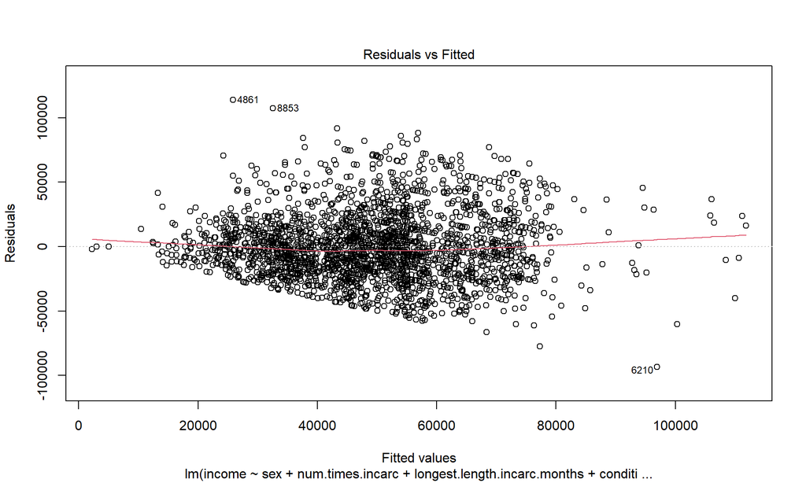

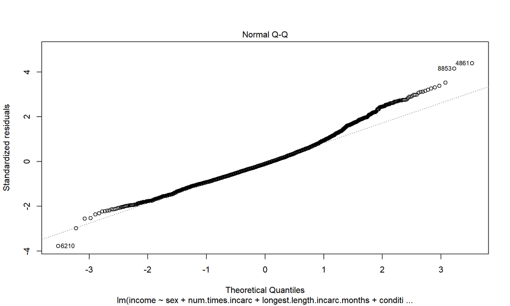

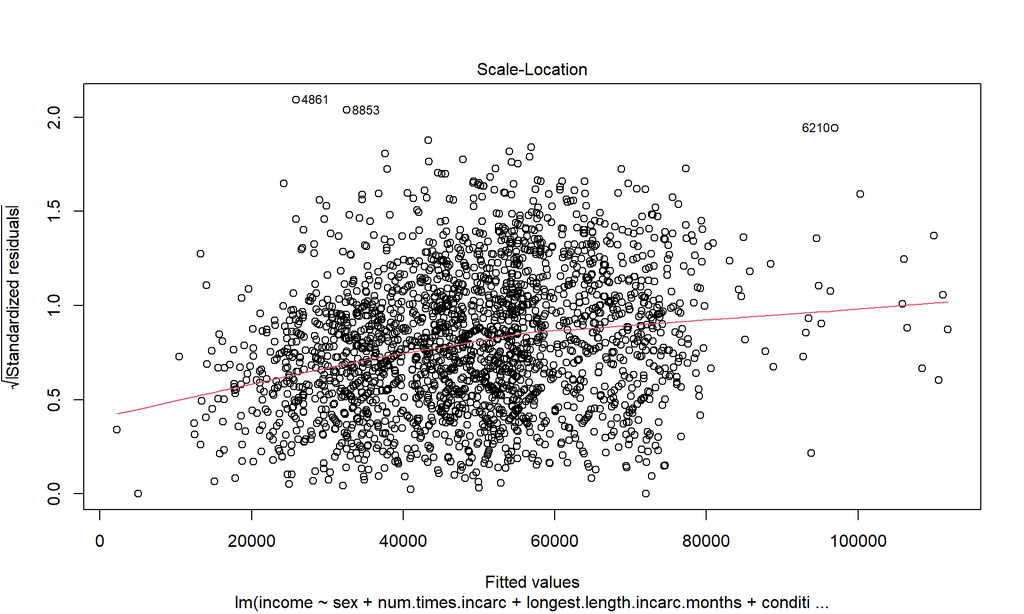

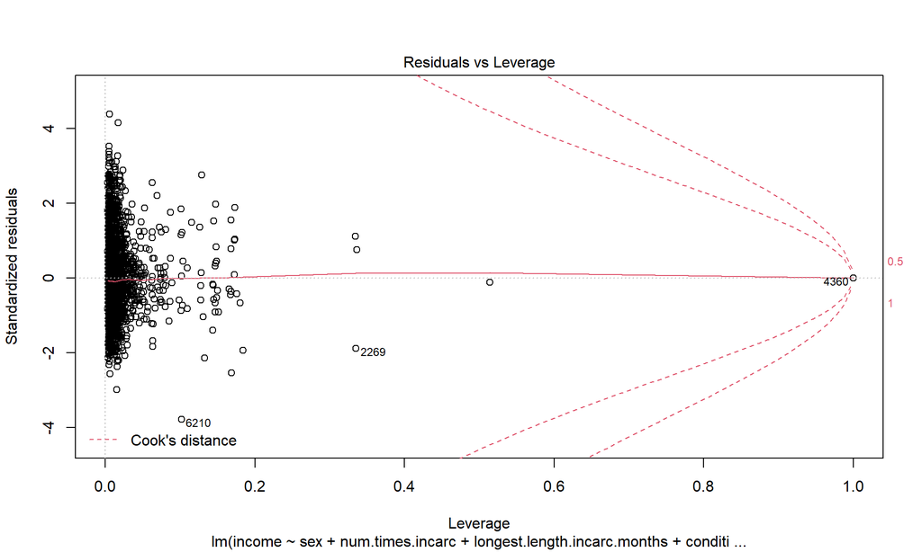

**Residual vs Fitted Plot**

The residual vs. fitted plot shows for the lower fitted values, there is clustering around 0 and as the fitted values increase, deviation away from a residual of 0 increases, this is very similar to Model #2, but the deviation appears to be slightly more pronounced.

**Normal QQ Plot**

The normal QQ plot shows an almost identical match to Model #2, suggesting that education already has a great degree of influence on the model and is accounted for in Model #2. It is difficult to find any noticable variation on either upper or lower tail of the range.

**Scale-Location Plot**

As the fitted values increase, the variance still increases steadily very similarly to Model #2 and #3 but the trends present seem to have shifted slightly rightward, and show the most variation from Models 2 and 3 in the upper end of the income range.

**Outliers & The Residuals vs Leverage Plot**

The residuals vs leverage plot show that many of the outliers in Model #2 clustered around 0 have a greater spread suggesting more leverage than in the initial model.

**Conclusions from the Plot**

Adding the `sex*education` coefficient appears to make very slight changes toward the lower and upper ends of the range with some outliers having additional leverage in the model with the interaction coefficient than without, but the addition of the coefficient does little to correct exisiting issues with the model and appears to be largely redundant.

**Predicted Income Gender Gap between Different Educational Attainment Levels with and without the Interaction Variable**

We see from looking at the predicted income gap regarding education from the main effects model that the values are actually quite close to what we saw in our model with the exception of the PhD education value, therefore this interaction term between `sex * highest.degree.earned` may be redundant.

| highest.degree.earned | income.gap |
| --- | --- |
| No Degree Earned | 18156 |
| GED | 10820 |
| High School Diploma | 15988 |
| Associate | 11865 |
| Bachelors | 15887 |
| Masters | 13362 |
| PhD | 10750 |
| Professional Degree (DDS, JD, MD) | 17290 |
| Non-Interview | 11406 |
| Invalid Skip | 3601 |

The estimates in income gaps between men and women of different educational backgrounds is largely accurate. These findings are similar to the findings in our model with the `sex*education` interaction variable. Education tends to cut the income gap slightly, but it underestimates the effect of a masters degree in reducing income inequality with the interaction model showing an inequality of 12,094 dollars and the main effects model estimating an inequality of 13,362 dollars and similarly it underestimates the effect of a professional degree with the interaction model showing an income inequality for professional degrees of 11,652 dollars as opposed to the 17,290 dollars estimated by the main effects model.

**Testing the Significance of Adding an Interaction Variable on the Sex * Highest Degree Earned Status Term**

To test whether a `sex * highest.degree.earned` interaction variable is redundant we tested the new model against our original main effects model with an ANOVA test.

```
## Analysis of Variance Table
##
## Model 1: income ~ sex + num.times.incarc + longest.length.incarc.months +
##     condition.limiting.work + citizenship + urban.status.age.12 +
##     residential.dad.highest.grade.completed + residential.mom.highest.grade.completed +
##     race + num.children.under.6 + highest.degree.earned + marital.status +
##     age.in.2017
## Model 2: income ~ sex + num.times.incarc + longest.length.incarc.months +
##     condition.limiting.work + citizenship + urban.status.age.12 +
##     residential.dad.highest.grade.completed + residential.mom.highest.grade.completed +
##     race + num.children.under.6 + highest.degree.earned + marital.status +
##     age.in.2017 + sex:highest.degree.earned
##   Res.Df           RSS Df  Sum of Sq      F Pr(>F)
## 1   2346 1595000619595
## 2   2337 1591771751744  9 3228867851 0.5267 0.8561
```

We see that the p-value of 0.8561254 is not even close to the threshold required to reject the null hypothesis. Therefore, we fail to reject the null hypothesis that the income gap between men and women is the same across similar educational attainment.

### Discussion

#### Main Conclusions

The variables for which there appeared to be a statistically significant impact on income (according to the second model in which the values were not topcoded) were: 1. `sex` 2. `num.times.incarc` 3. `residential.mom.highest.grade.completed` 4. `race`, if the respondent is Black 5. `highest.degree.earned` and, 6. `marital.status`, if the respondent is married, and 7. `education`.

When running our first linear regression model on the dataset with topcoded income variables, there were some significant issues with the fit of the model to the data. Removing the topcoded values was helpful in rectifying many of those problems. Despite the noticeable improvements, however, issues remained with residuals toward the top and bottom of the income range not fitting the model.

In order to address those issues, we looked at some of the most statistically significant factors effecting income and reviewed the data from each. After an initial review we saw significant effects from `num.times.incarc`, `longest.length.incarc.months`, `race`, `marital.status`, and `education` in income discrepancies based on sex. We ran regressions on each of these variables and created interaction terms with sex to see the effect.

**Models 3 & 4: Number of Times Incarcerated and Length of Incarceration**

From the results of the regression, it appears that, despite more men having a criminal history and being incarcerated longer than women, this did not result in a statistically significant difference in income between men and women in the sample of the dataset that was examined.

**Model 5: Race**

Across all models except, Model #1, a pattern of statistically significant results of lower incomes persisted for Black respondents. Even when interacting race and sex, this pattern persisted. This was not true for other racial groups, suggesting Black respondents face patterns of discrimination which effects their income even when controlling for other factors.

**Model 6: Marital Status**

The results indicate that marital status does result in a statistically significant difference in earnings between men and women and that the difference in earnings is not uniform across the various marital statuses, with female widowers seeing a steeper drop in earnings than their male counterparts, and women who are separated seeing a boost in income where their male counterparts saw a steep drop.

The addition of the `marital.status*sex` term corrected for some of the deviations from the model at the top of the income range and the combination of the removal of top coding from the income variable and addition of the interaction term `marital.status*sex` produced our most accurate model.

However, the small sample size of widowed and separated participants likely effects the reliability of these results.

**Model 7: Education**

We additionally see that education is the most effective way to increase income for both men and women. Specifically, as educational attainment rises, the income gap on the basis of sex generally shrinks. However, there are diminishing returns to educational attainment, as the income gap between men and women is greatest between male and female PhDs.

#### Other Potential Confounders

The geographical region in which this analysis was done could serve as a confounder in the models. It appeared that most of the participants selected for this study appeared to have lived (at the age of 12) in an urban area, which could have influenced the kinds of resources they had access to. It also would have been helpful to have information on the types of crimes that respondents had committed (i.e. misdemeanors, white collar crimes, felonies) to get a better understanding of the influence of criminal history and gender on income. There are greater barriers to entry in the job market for individuals who have felonies than misdemeanors which could have explained some of the outlier behavior we observed, in terms of the individuals who had substantial incarceration histories but had high incomes.

Another challenge with this dataset is the time dimension. Most variables are collected at a specific point in time. For example, the urban vs. rural variable is specific to where the respondent lived when they were 12. It is possible that residence type has a stronger impact later in life, but this information wasn’t collected.

Another variable worth discussing is citizenship. The definition of citizenship in the codebook is tied to birthplace. However, respondents could be born outside of the U.S. and be a U.S. citizen. These definitions challenge our model findings for citizenship status.

Variables regarding the presence of children in the household offered only limited context on how children might affect income and did not account for adoption, or children with special needs. Additionally information on age of the children in the house being limited to 6 represents a limiting factor toward understanding the effect childcare has on income.

#### Model Soundness

Some of our results had clear trends that can be expressed with a reasonable degree of confidence. Results showing discrepancies in income between men and women across racial background, educational attainment, and incarceration status were persistent. There was also a persistent trend showing discrepancies in income on the basis of racial/ethnic background. While these results appear for all groups that were Non-Black/Non-Hispanic, they were most statistically significant for Black respondents. This result was consistent. The sample size of Black respondents was sufficient to make a strong argument that racial discrimination against Black respondents has a statistically significant effect on income.

In many cases where there were significant results skewing the original model, they came from groups with small sample sizes. Analysis on groups like widows, Mixed Race, Non-Hispanic persons, people with lengthy incarcerations, and men and women with multiple children require greater analysis with a larger sample size before a confident assertion of the results found could be stated.

Our models do a reasonably good job of accommodating these questions around sample size, but limitations exist in some areas where troubling trends exist and need to be further studied.

Despite some of the limitations of the dataset, the findings of our analysis could start a conversation about the stark differences in income according to gender. These conversations could allow policymakers to begin to think about potential avenues for intervention that could curb the effect of this trend.